# Risk Factor Analysis

## Outcome Variable

**Outcome Variable:** ever_wasted

## Predictor Variables

**Intervention Variable:** impsan

**Adjustment Set:**

- arm
- sex
- W_mage
- meducyrs
- feducyrs
- hhwealth_quart
- hfoodsec
- W_mhtcm
- W_mwtkg
- W_mbmi
- W_nrooms
- W_nchldlt5
- W_parity
- impfloor
- safeh20
- delta_W_mage
- delta_meducyrs
- delta_feducyrs
- delta_hhwealth_quart
- delta_hfoodsec
- delta_W_mhtcm
- delta_W_mwtkg
- delta_W_mbmi
- delta_W_nrooms
- delta_W_nchldlt5
- delta_W_parity
- delta_impfloor
- delta_safeh20

## Stratifying Variables

The analysis was stratified on these variable(s):

- agecat
- studyid
- country

## Data Summary

| agecat | studyid | country | impsan | ever_wasted | n_cell | n |
| --- | --- | --- | --- | --- | --- | --- |
| 0-24 months (no birth wast) | COHORTS | GUATEMALA | 1 | 0 | 73 | 870 |
| 0-24 months (no birth wast) | COHORTS | GUATEMALA | 1 | 1 | 8 | 870 |
| 0-24 months (no birth wast) | COHORTS | GUATEMALA | 0 | 0 | 666 | 870 |
| 0-24 months (no birth wast) | COHORTS | GUATEMALA | 0 | 1 | 123 | 870 |
| 0-24 months (no birth wast) | COHORTS | INDIA | 1 | 0 | 1675 | 5168 |
| 0-24 months (no birth wast) | COHORTS | INDIA | 1 | 1 | 291 | 5168 |
| 0-24 months (no birth wast) | COHORTS | INDIA | 0 | 0 | 2500 | 5168 |
| 0-24 months (no birth wast) | COHORTS | INDIA | 0 | 1 | 702 | 5168 |
| 0-24 months (no birth wast) | COHORTS | PHILIPPINES | 1 | 0 | 142 | 1185 |
| 0-24 months (no birth wast) | COHORTS | PHILIPPINES | 1 | 1 | 37 | 1185 |
| 0-24 months (no birth wast) | COHORTS | PHILIPPINES | 0 | 0 | 661 | 1185 |
| 0-24 months (no birth wast) | COHORTS | PHILIPPINES | 0 | 1 | 345 | 1185 |
| 0-24 months (no birth wast) | CONTENT | PERU | 1 | 0 | 197 | 215 |
| 0-24 months (no birth wast) | CONTENT | PERU | 1 | 1 | 4 | 215 |
| 0-24 months (no birth wast) | CONTENT | PERU | 0 | 0 | 14 | 215 |
| 0-24 months (no birth wast) | CONTENT | PERU | 0 | 1 | 0 | 215 |
| 0-24 months (no birth wast) | JiVitA-3 | BANGLADESH | 1 | 0 | 15464 | 26502 |
| 0-24 months (no birth wast) | JiVitA-3 | BANGLADESH | 1 | 1 | 3047 | 26502 |
| 0-24 months (no birth wast) | JiVitA-3 | BANGLADESH | 0 | 0 | 6551 | 26502 |
| 0-24 months (no birth wast) | JiVitA-3 | BANGLADESH | 0 | 1 | 1440 | 26502 |
| 0-24 months (no birth wast) | JiVitA-4 | BANGLADESH | 1 | 0 | 3144 | 5381 |
| 0-24 months (no birth wast) | JiVitA-4 | BANGLADESH | 1 | 1 | 1017 | 5381 |
| 0-24 months (no birth wast) | JiVitA-4 | BANGLADESH | 0 | 0 | 850 | 5381 |
| 0-24 months (no birth wast) | JiVitA-4 | BANGLADESH | 0 | 1 | 370 | 5381 |
| 0-24 months (no birth wast) | LCNI-5 | MALAWI | 1 | 0 | 3 | 810 |
| 0-24 months (no birth wast) | LCNI-5 | MALAWI | 1 | 1 | 0 | 810 |
| 0-24 months (no birth wast) | LCNI-5 | MALAWI | 0 | 0 | 753 | 810 |
| 0-24 months (no birth wast) | LCNI-5 | MALAWI | 0 | 1 | 54 | 810 |
| 0-24 months (no birth wast) | MAL-ED | BANGLADESH | 1 | 0 | 157 | 242 |
| 0-24 months (no birth wast) | MAL-ED | BANGLADESH | 1 | 1 | 47 | 242 |

[output cut: 106 more lines]

The following strata were considered:

- agecat: 0-24 months (no birth wast), studyid: COHORTS, country: GUATEMALA
- agecat: 0-24 months (no birth wast), studyid: COHORTS, country: INDIA
- agecat: 0-24 months (no birth wast), studyid: COHORTS, country: PHILIPPINES
- agecat: 0-24 months (no birth wast), studyid: CONTENT, country: PERU
- agecat: 0-24 months (no birth wast), studyid: JiVitA-3, country: BANGLADESH
- agecat: 0-24 months (no birth wast), studyid: JiVitA-4, country: BANGLADESH
- agecat: 0-24 months (no birth wast), studyid: LCNI-5, country: MALAWI
- agecat: 0-24 months (no birth wast), studyid: MAL-ED, country: BANGLADESH
- agecat: 0-24 months (no birth wast), studyid: MAL-ED, country: BRAZIL
- agecat: 0-24 months (no birth wast), studyid: MAL-ED, country: INDIA
- agecat: 0-24 months (no birth wast), studyid: MAL-ED, country: NEPAL
- agecat: 0-24 months (no birth wast), studyid: MAL-ED, country: PERU
- agecat: 0-24 months (no birth wast), studyid: MAL-ED, country: SOUTH AFRICA
- agecat: 0-24 months (no birth wast), studyid: MAL-ED, country: TANZANIA, UNITED REPUBLIC OF
- agecat: 0-24 months (no birth wast), studyid: NIH-Birth, country: BANGLADESH
- agecat: 0-24 months (no birth wast), studyid: NIH-Crypto, country: BANGLADESH
- agecat: 0-24 months (no birth wast), studyid: PROVIDE, country: BANGLADESH
- agecat: 0-6 months (no birth wast), studyid: COHORTS, country: GUATEMALA
- agecat: 0-6 months (no birth wast), studyid: COHORTS, country: INDIA
- agecat: 0-6 months (no birth wast), studyid: COHORTS, country: PHILIPPINES
- agecat: 0-6 months (no birth wast), studyid: CONTENT, country: PERU
- agecat: 0-6 months (no birth wast), studyid: JiVitA-3, country: BANGLADESH
- agecat: 0-6 months (no birth wast), studyid: JiVitA-4, country: BANGLADESH
- agecat: 0-6 months (no birth wast), studyid: LCNI-5, country: MALAWI
- agecat: 0-6 months (no birth wast), studyid: MAL-ED, country: BANGLADESH
- agecat: 0-6 months (no birth wast), studyid: MAL-ED, country: BRAZIL
- agecat: 0-6 months (no birth wast), studyid: MAL-ED, country: INDIA
- agecat: 0-6 months (no birth wast), studyid: MAL-ED, country: NEPAL
- agecat: 0-6 months (no birth wast), studyid: MAL-ED, country: PERU
- agecat: 0-6 months (no birth wast), studyid: MAL-ED, country: SOUTH AFRICA
- agecat: 0-6 months (no birth wast), studyid: MAL-ED, country: TANZANIA, UNITED REPUBLIC OF
- agecat: 0-6 months (no birth wast), studyid: NIH-Birth, country: BANGLADESH
- agecat: 0-6 months (no birth wast), studyid: NIH-Crypto, country: BANGLADESH
- agecat: 0-6 months (no birth wast), studyid: PROVIDE, country: BANGLADESH

### Dropped Strata

Some strata were dropped due to rare outcomes:

- agecat: 0-24 months (no birth wast), studyid: CONTENT, country: PERU
- agecat: 0-24 months (no birth wast), studyid: LCNI-5, country: MALAWI
- agecat: 0-24 months (no birth wast), studyid: MAL-ED, country: BRAZIL
- agecat: 0-24 months (no birth wast), studyid: MAL-ED, country: NEPAL
- agecat: 0-24 months (no birth wast), studyid: MAL-ED, country: SOUTH AFRICA
- agecat: 0-24 months (no birth wast), studyid: MAL-ED, country: TANZANIA, UNITED REPUBLIC OF
- agecat: 0-24 months (no birth wast), studyid: PROVIDE, country: BANGLADESH
- agecat: 0-6 months (no birth wast), studyid: COHORTS, country: GUATEMALA
- agecat: 0-6 months (no birth wast), studyid: CONTENT, country: PERU
- agecat: 0-6 months (no birth wast), studyid: LCNI-5, country: MALAWI
- agecat: 0-6 months (no birth wast), studyid: MAL-ED, country: BANGLADESH
- agecat: 0-6 months (no birth wast), studyid: MAL-ED, country: BRAZIL
- agecat: 0-6 months (no birth wast), studyid: MAL-ED, country: NEPAL
- agecat: 0-6 months (no birth wast), studyid: MAL-ED, country: PERU
- agecat: 0-6 months (no birth wast), studyid: MAL-ED, country: SOUTH AFRICA
- agecat: 0-6 months (no birth wast), studyid: MAL-ED, country: TANZANIA, UNITED REPUBLIC OF
- agecat: 0-6 months (no birth wast), studyid: NIH-Crypto, country: BANGLADESH
- agecat: 0-6 months (no birth wast), studyid: PROVIDE, country: BANGLADESH

## Methods Detail

We're interested in the causal parameters $E[Y_a]$ for all values of $a \in \mathcal{A}$. These parameters represent the mean outcome if, possibly contrary to fact, we intervened to set all units to have $A=a$. Under the randomization and positivity assumptions, these are identified by the statistical parameters $\psi_a=E_W[E_{Y|A,W}(Y|A=a,W)]$. In addition, we're interested in the mean of $Y$, $E[Y]$ under no intervention (the observed mean). We will estimate these parameters by using SuperLearner to fit the relevant likelihood factors -- $E_{Y|A,W}(Y|A=a,W)$ and $p(A=a|W)$, and then updating our likelihood fit using a joint TMLE.

For unadjusted analyses ($W=\{\}$), initial likelihoods were estimated using Lrnr_glm to estimate the simple $E(Y|A)$ and Lrnr_mean to estimate $p(A)$. For adjusted analyses, a small library containing Lrnr_glmnet, Lrnr_xgboost, and Lrnr_mean was used.

Having estimated these parameters, we will then use the delta method to estimate relative risks and attributable risks relative to a prespecified baseline level of $A$.

# Results Detail

## Results Plots

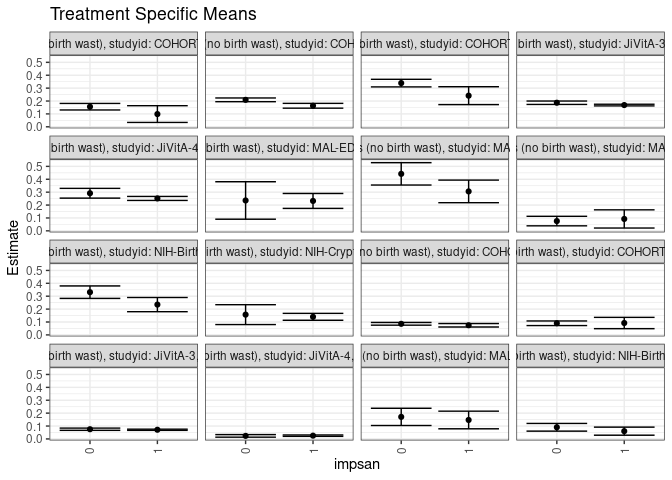

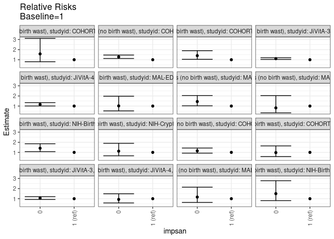

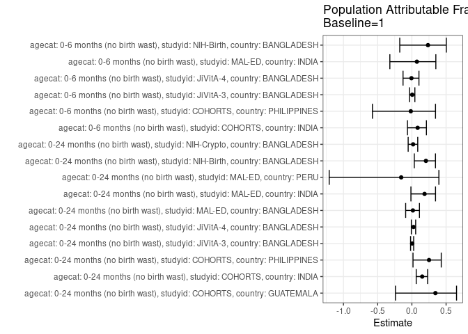

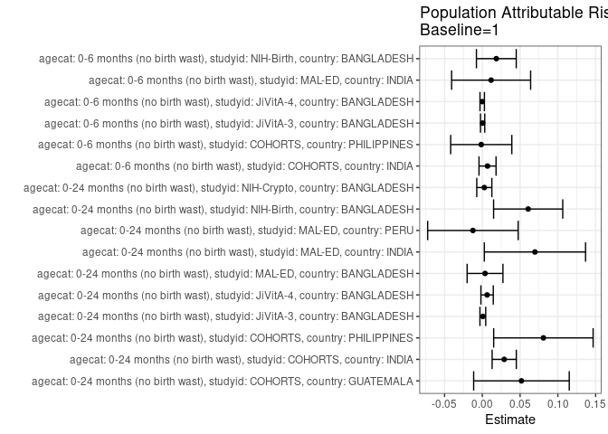

## Results Table

### Parameter: TSM

| agecat | studyid | country | intervention_level | baseline_level | estimate | ci_lower | ci_upper |
| --- | --- | --- | --- | --- | --- | --- | --- |
| 0-24 months (no birth wast) | COHORTS | GUATEMALA | 1 | NA | 0.0987654 | 0.0337559 | 0.1637749 |
| 0-24 months (no birth wast) | COHORTS | GUATEMALA | 0 | NA | 0.1558935 | 0.1305672 | 0.1812199 |
| 0-24 months (no birth wast) | COHORTS | INDIA | 1 | NA | 0.1631476 | 0.1445632 | 0.1817320 |
| 0-24 months (no birth wast) | COHORTS | INDIA | 0 | NA | 0.2090983 | 0.1946477 | 0.2235490 |
| 0-24 months (no birth wast) | COHORTS | PHILIPPINES | 1 | NA | 0.2415003 | 0.1722926 | 0.3107079 |
| 0-24 months (no birth wast) | COHORTS | PHILIPPINES | 0 | NA | 0.3390829 | 0.3096337 | 0.3685322 |
| 0-24 months (no birth wast) | JiVitA-3 | BANGLADESH | 1 | NA | 0.1686430 | 0.1620658 | 0.1752201 |
| 0-24 months (no birth wast) | JiVitA-3 | BANGLADESH | 0 | NA | 0.1867349 | 0.1734812 | 0.1999887 |
| 0-24 months (no birth wast) | JiVitA-4 | BANGLADESH | 1 | NA | 0.2514533 | 0.2358632 | 0.2670433 |
| 0-24 months (no birth wast) | JiVitA-4 | BANGLADESH | 0 | NA | 0.2915990 | 0.2536814 | 0.3295166 |
| 0-24 months (no birth wast) | MAL-ED | BANGLADESH | 1 | NA | 0.2319482 | 0.1740400 | 0.2898564 |
| 0-24 months (no birth wast) | MAL-ED | BANGLADESH | 0 | NA | 0.2356458 | 0.0903446 | 0.3809470 |
| 0-24 months (no birth wast) | MAL-ED | INDIA | 1 | NA | 0.3058687 | 0.2183082 | 0.3934291 |
| 0-24 months (no birth wast) | MAL-ED | INDIA | 0 | NA | 0.4419695 | 0.3551369 | 0.5288020 |
| 0-24 months (no birth wast) | MAL-ED | PERU | 1 | NA | 0.0923077 | 0.0218048 | 0.1628106 |
| 0-24 months (no birth wast) | MAL-ED | PERU | 0 | NA | 0.0757576 | 0.0388302 | 0.1126850 |
| 0-24 months (no birth wast) | NIH-Birth | BANGLADESH | 1 | NA | 0.2349747 | 0.1799764 | 0.2899729 |
| 0-24 months (no birth wast) | NIH-Birth | BANGLADESH | 0 | NA | 0.3312817 | 0.2829582 | 0.3796052 |
| 0-24 months (no birth wast) | NIH-Crypto | BANGLADESH | 1 | NA | 0.1400407 | 0.1133378 | 0.1667435 |
| 0-24 months (no birth wast) | NIH-Crypto | BANGLADESH | 0 | NA | 0.1570743 | 0.0800163 | 0.2341324 |
| 0-6 months (no birth wast) | COHORTS | INDIA | 1 | NA | 0.0746248 | 0.0612335 | 0.0880162 |
| 0-6 months (no birth wast) | COHORTS | INDIA | 0 | NA | 0.0857436 | 0.0752261 | 0.0962611 |
| 0-6 months (no birth wast) | COHORTS | PHILIPPINES | 1 | NA | 0.0920968 | 0.0482672 | 0.1359265 |
| 0-6 months (no birth wast) | COHORTS | PHILIPPINES | 0 | NA | 0.0902630 | 0.0724280 | 0.1080979 |
| 0-6 months (no birth wast) | JiVitA-3 | BANGLADESH | 1 | NA | 0.0712721 | 0.0667124 | 0.0758318 |
| 0-6 months (no birth wast) | JiVitA-3 | BANGLADESH | 0 | NA | 0.0752701 | 0.0666212 | 0.0839191 |
| 0-6 months (no birth wast) | JiVitA-4 | BANGLADESH | 1 | NA | 0.0254325 | 0.0201356 | 0.0307295 |
| 0-6 months (no birth wast) | JiVitA-4 | BANGLADESH | 0 | NA | 0.0236397 | 0.0138097 | 0.0334697 |
| 0-6 months (no birth wast) | MAL-ED | INDIA | 1 | NA | 0.1469524 | 0.0785349 | 0.2153699 |
| 0-6 months (no birth wast) | MAL-ED | INDIA | 0 | NA | 0.1710257 | 0.1042364 | 0.2378151 |
| 0-6 months (no birth wast) | NIH-Birth | BANGLADESH | 1 | NA | 0.0602198 | 0.0289519 | 0.0914877 |
| 0-6 months (no birth wast) | NIH-Birth | BANGLADESH | 0 | NA | 0.0903835 | 0.0604496 | 0.1203174 |

### Parameter: E(Y)

| agecat | studyid | country | intervention_level | baseline_level | estimate | ci_lower | ci_upper |
| --- | --- | --- | --- | --- | --- | --- | --- |
| 0-24 months (no birth wast) | COHORTS | GUATEMALA | NA | NA | 0.1505747 | 0.1267966 | 0.1743528 |
| 0-24 months (no birth wast) | COHORTS | INDIA | NA | NA | 0.1921440 | 0.1814014 | 0.2028866 |
| 0-24 months (no birth wast) | COHORTS | PHILIPPINES | NA | NA | 0.3223629 | 0.2957407 | 0.3489850 |
| 0-24 months (no birth wast) | JiVitA-3 | BANGLADESH | NA | NA | 0.1693080 | 0.1640179 | 0.1745980 |
| 0-24 months (no birth wast) | JiVitA-4 | BANGLADESH | NA | NA | 0.2577588 | 0.2441239 | 0.2713937 |
| 0-24 months (no birth wast) | MAL-ED | BANGLADESH | NA | NA | 0.2355372 | 0.1819640 | 0.2891104 |
| 0-24 months (no birth wast) | MAL-ED | INDIA | NA | NA | 0.3755459 | 0.3126876 | 0.4384041 |
| 0-24 months (no birth wast) | MAL-ED | PERU | NA | NA | 0.0798479 | 0.0470264 | 0.1126695 |
| 0-24 months (no birth wast) | NIH-Birth | BANGLADESH | NA | NA | 0.2956811 | 0.2591967 | 0.3321655 |
| 0-24 months (no birth wast) | NIH-Crypto | BANGLADESH | NA | NA | 0.1426649 | 0.1175009 | 0.1678289 |
| 0-6 months (no birth wast) | COHORTS | INDIA | NA | NA | 0.0815160 | 0.0737115 | 0.0893204 |
| 0-6 months (no birth wast) | COHORTS | PHILIPPINES | NA | NA | 0.0906780 | 0.0742871 | 0.1070688 |
| 0-6 months (no birth wast) | JiVitA-3 | BANGLADESH | NA | NA | 0.0716602 | 0.0680237 | 0.0752968 |
| 0-6 months (no birth wast) | JiVitA-4 | BANGLADESH | NA | NA | 0.0252781 | 0.0205710 | 0.0299851 |
| 0-6 months (no birth wast) | MAL-ED | INDIA | NA | NA | 0.1585903 | 0.1109652 | 0.2062154 |
| 0-6 months (no birth wast) | NIH-Birth | BANGLADESH | NA | NA | 0.0787671 | 0.0569010 | 0.1006332 |

### Parameter: RR

| agecat | studyid | country | intervention_level | baseline_level | estimate | ci_lower | ci_upper |
| --- | --- | --- | --- | --- | --- | --- | --- |
| 0-24 months (no birth wast) | COHORTS | GUATEMALA | 1 | 1 | 1.0000000 | 1.0000000 | 1.000000 |
| 0-24 months (no birth wast) | COHORTS | GUATEMALA | 0 | 1 | 1.5784221 | 0.8012777 | 3.109304 |
| 0-24 months (no birth wast) | COHORTS | INDIA | 1 | 1 | 1.0000000 | 1.0000000 | 1.000000 |
| 0-24 months (no birth wast) | COHORTS | INDIA | 0 | 1 | 1.2816513 | 1.1220898 | 1.463902 |
| 0-24 months (no birth wast) | COHORTS | PHILIPPINES | 1 | 1 | 1.0000000 | 1.0000000 | 1.000000 |
| 0-24 months (no birth wast) | COHORTS | PHILIPPINES | 0 | 1 | 1.4040685 | 1.0407782 | 1.894168 |
| 0-24 months (no birth wast) | JiVitA-3 | BANGLADESH | 1 | 1 | 1.0000000 | 1.0000000 | 1.000000 |
| 0-24 months (no birth wast) | JiVitA-3 | BANGLADESH | 0 | 1 | 1.1072797 | 1.0250344 | 1.196124 |
| 0-24 months (no birth wast) | JiVitA-4 | BANGLADESH | 1 | 1 | 1.0000000 | 1.0000000 | 1.000000 |
| 0-24 months (no birth wast) | JiVitA-4 | BANGLADESH | 0 | 1 | 1.1596547 | 1.0069519 | 1.335515 |
| 0-24 months (no birth wast) | MAL-ED | BANGLADESH | 1 | 1 | 1.0000000 | 1.0000000 | 1.000000 |
| 0-24 months (no birth wast) | MAL-ED | BANGLADESH | 0 | 1 | 1.0159417 | 0.5233348 | 1.972232 |
| 0-24 months (no birth wast) | MAL-ED | INDIA | 1 | 1 | 1.0000000 | 1.0000000 | 1.000000 |
| 0-24 months (no birth wast) | MAL-ED | INDIA | 0 | 1 | 1.4449649 | 1.0237307 | 2.039524 |
| 0-24 months (no birth wast) | MAL-ED | PERU | 1 | 1 | 1.0000000 | 1.0000000 | 1.000000 |
| 0-24 months (no birth wast) | MAL-ED | PERU | 0 | 1 | 0.8207071 | 0.3316556 | 2.030902 |
| 0-24 months (no birth wast) | NIH-Birth | BANGLADESH | 1 | 1 | 1.0000000 | 1.0000000 | 1.000000 |
| 0-24 months (no birth wast) | NIH-Birth | BANGLADESH | 0 | 1 | 1.4098613 | 1.0724152 | 1.853488 |
| 0-24 months (no birth wast) | NIH-Crypto | BANGLADESH | 1 | 1 | 1.0000000 | 1.0000000 | 1.000000 |
| 0-24 months (no birth wast) | NIH-Crypto | BANGLADESH | 0 | 1 | 1.1216338 | 0.6620192 | 1.900341 |
| 0-6 months (no birth wast) | COHORTS | INDIA | 1 | 1 | 1.0000000 | 1.0000000 | 1.000000 |
| 0-6 months (no birth wast) | COHORTS | INDIA | 0 | 1 | 1.1489953 | 0.9245180 | 1.427977 |
| 0-6 months (no birth wast) | COHORTS | PHILIPPINES | 1 | 1 | 1.0000000 | 1.0000000 | 1.000000 |
| 0-6 months (no birth wast) | COHORTS | PHILIPPINES | 0 | 1 | 0.9800875 | 0.5853702 | 1.640964 |
| 0-6 months (no birth wast) | JiVitA-3 | BANGLADESH | 1 | 1 | 1.0000000 | 1.0000000 | 1.000000 |
| 0-6 months (no birth wast) | JiVitA-3 | BANGLADESH | 0 | 1 | 1.0560957 | 0.9275567 | 1.202447 |
| 0-6 months (no birth wast) | JiVitA-4 | BANGLADESH | 1 | 1 | 1.0000000 | 1.0000000 | 1.000000 |
| 0-6 months (no birth wast) | JiVitA-4 | BANGLADESH | 0 | 1 | 0.9295072 | 0.5825911 | 1.483002 |
| 0-6 months (no birth wast) | MAL-ED | INDIA | 1 | 1 | 1.0000000 | 1.0000000 | 1.000000 |
| 0-6 months (no birth wast) | MAL-ED | INDIA | 0 | 1 | 1.1638172 | 0.6321132 | 2.142766 |
| 0-6 months (no birth wast) | NIH-Birth | BANGLADESH | 1 | 1 | 1.0000000 | 1.0000000 | 1.000000 |
| 0-6 months (no birth wast) | NIH-Birth | BANGLADESH | 0 | 1 | 1.5008937 | 0.8107882 | 2.778385 |

### Parameter: PAR

| agecat | studyid | country | intervention_level | baseline_level | estimate | ci_lower | ci_upper |
| --- | --- | --- | --- | --- | --- | --- | --- |
| 0-24 months (no birth wast) | COHORTS | GUATEMALA | 1 | NA | 0.0518093 | -0.0114732 | 0.1150918 |
| 0-24 months (no birth wast) | COHORTS | INDIA | 1 | NA | 0.0289964 | 0.0129799 | 0.0450128 |
| 0-24 months (no birth wast) | COHORTS | PHILIPPINES | 1 | NA | 0.0808626 | 0.0150248 | 0.1467004 |
| 0-24 months (no birth wast) | JiVitA-3 | BANGLADESH | 1 | NA | 0.0006650 | -0.0031537 | 0.0044837 |
| 0-24 months (no birth wast) | JiVitA-4 | BANGLADESH | 1 | NA | 0.0063055 | -0.0018863 | 0.0144973 |
| 0-24 months (no birth wast) | MAL-ED | BANGLADESH | 1 | NA | 0.0035890 | -0.0201164 | 0.0272944 |
| 0-24 months (no birth wast) | MAL-ED | INDIA | 1 | NA | 0.0696772 | 0.0026506 | 0.1367038 |
| 0-24 months (no birth wast) | MAL-ED | PERU | 1 | NA | -0.0124598 | -0.0723842 | 0.0474646 |
| 0-24 months (no birth wast) | NIH-Birth | BANGLADESH | 1 | NA | 0.0607064 | 0.0149213 | 0.1064914 |
| 0-24 months (no birth wast) | NIH-Crypto | BANGLADESH | 1 | NA | 0.0026242 | -0.0073615 | 0.0126099 |
| 0-6 months (no birth wast) | COHORTS | INDIA | 1 | NA | 0.0068911 | -0.0043838 | 0.0181661 |
| 0-6 months (no birth wast) | COHORTS | PHILIPPINES | 1 | NA | -0.0014189 | -0.0418922 | 0.0390544 |
| 0-6 months (no birth wast) | JiVitA-3 | BANGLADESH | 1 | NA | 0.0003882 | -0.0024229 | 0.0031992 |
| 0-6 months (no birth wast) | JiVitA-4 | BANGLADESH | 1 | NA | -0.0001545 | -0.0030860 | 0.0027771 |
| 0-6 months (no birth wast) | MAL-ED | INDIA | 1 | NA | 0.0116379 | -0.0406712 | 0.0639470 |
| 0-6 months (no birth wast) | NIH-Birth | BANGLADESH | 1 | NA | 0.0185473 | -0.0078041 | 0.0448988 |

### Parameter: PAF

| agecat | studyid | country | intervention_level | baseline_level | estimate | ci_lower | ci_upper |
| --- | --- | --- | --- | --- | --- | --- | --- |
| 0-24 months (no birth wast) | COHORTS | GUATEMALA | 1 | NA | 0.3440769 | -0.2397390 | 0.6529632 |
| 0-24 months (no birth wast) | COHORTS | INDIA | 1 | NA | 0.1509095 | 0.0635715 | 0.2301017 |
| 0-24 months (no birth wast) | COHORTS | PHILIPPINES | 1 | NA | 0.2508434 | 0.0166463 | 0.4292637 |
| 0-24 months (no birth wast) | JiVitA-3 | BANGLADESH | 1 | NA | 0.0039278 | -0.0188867 | 0.0262314 |
| 0-24 months (no birth wast) | JiVitA-4 | BANGLADESH | 1 | NA | 0.0244629 | -0.0078090 | 0.0557013 |
| 0-24 months (no birth wast) | MAL-ED | BANGLADESH | 1 | NA | 0.0152376 | -0.0906765 | 0.1108665 |
| 0-24 months (no birth wast) | MAL-ED | INDIA | 1 | NA | 0.1855358 | -0.0138065 | 0.3456819 |
| 0-24 months (no birth wast) | MAL-ED | PERU | 1 | NA | -0.1560440 | -1.2084404 | 0.3948500 |
| 0-24 months (no birth wast) | NIH-Birth | BANGLADESH | 1 | NA | 0.2053103 | 0.0355431 | 0.3451945 |
| 0-24 months (no birth wast) | NIH-Crypto | BANGLADESH | 1 | NA | 0.0183943 | -0.0540986 | 0.0859016 |
| 0-6 months (no birth wast) | COHORTS | INDIA | 1 | NA | 0.0845372 | -0.0645840 | 0.2127704 |
| 0-6 months (no birth wast) | COHORTS | PHILIPPINES | 1 | NA | -0.0156475 | -0.5761259 | 0.3455219 |
| 0-6 months (no birth wast) | JiVitA-3 | BANGLADESH | 1 | NA | 0.0054166 | -0.0345915 | 0.0438776 |
| 0-6 months (no birth wast) | JiVitA-4 | BANGLADESH | 1 | NA | -0.0061115 | -0.1291633 | 0.1035305 |
| 0-6 months (no birth wast) | MAL-ED | INDIA | 1 | NA | 0.0733834 | -0.3217990 | 0.3504169 |
| 0-6 months (no birth wast) | NIH-Birth | BANGLADESH | 1 | NA | 0.2354706 | -0.1769739 | 0.5033831 |